# Data Open Lecture: An Introduction of R

# Demo Tutorial of Igraph

- Find and run the demo in igraph

```r
demo(package = "igraph")
demo("centrality", package = "igraph")
```

- Use interactive version igraphdemo()

```r
igraphdemo("centrality")
```

# 5.2 Summarize Network

# Read Network Data

- Data: A sample of 4000+ Facebook friends (mutual)

```r
datag = read.graph("Rlecture_data_facebook.txt", format = "edgelist")
datag = as.undirected(datag)
datag
```

- Take a subgraph from the original graph for analysis

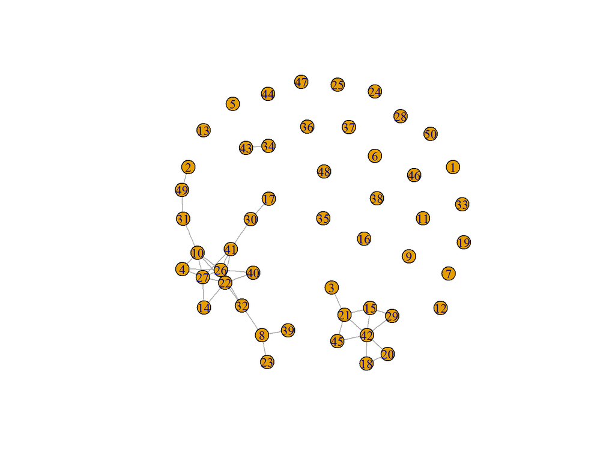

```r
datag_sub = induced.subgraph(datag, 1:50)
datag_sub
V(datag_sub)
E(datag_sub)
plot(datag_sub, vertex.size = 10, edge.arrow.size = 0.3)
```

# Neighbour and Path

- Neighbours: The set of vertices directly connected to a vertex

```r
V(datag)[nei(1)] # The vertices vertex 1 is connected with
```

```
## + 2/4039 vertices:
## [1]  59 172
```

- The shortest path to pass from one vertex to another vertex

```r
shortest.paths(datag, v = 4, to = 10) # The shortest path from vertex 4 to vertex 10
```

```
##      [,1]
## [1,]    1
```

```r
shortest.paths(datag, v = 1:5, to = 1:10) # The shortest path from vertex 1~5 to vertex 1~10
```

```
##      [,1] [,2] [,3] [,4] [,5] [,6] [,7] [,8] [,9] [,10]
## [1,]    0    3    7    4    5    4    7    4    7     3
## [2,]    3    0    6    2    4    2    6    2    6     2
## [3,]    7    6    0    5    7    6    4    5    4     5
## [4,]    4    2    5    0    5    2    6    3    5     1
## [5,]    5    4    7    5    0    4    7    3    7     4
```

# Adjacency Matrix

- Adjecency Matrix: the existence of edge between any two vertices

```r
am = get.adjacency(datag)
am[1:10, 1:10]
```

```
## 10 x 10 sparse Matrix of class "dgCMatrix"
##
##  [1,] . . . . . . . . . .
##  [2,] . . . . . . . . . .
##  [3,] . . . . . . . . . .
##  [4,] . . . . . . . . . 1
##  [5,] . . . . . . . . . .
##  [6,] . . . . . . . . . .
##  [7,] . . . . . . . . . .
##  [8,] . . . . . . . . . .
##  [9,] . . . . . . . . . .
## [10,] . . . 1 . . . . . .
```

- Matrix power of adjecency matrix $A^p$: the total number of p-path between any two vertices

```r
am2 = am%*%am
am2[1:10, 1:10]
```

# Measurements of Network Centrality (1)

- Degree $C_D(v)$: the number of edges of a vertex

```r
vdegree = degree(datag)
head(vdegree) # The degree of first 6 vertices
```

```
## [1]  2 16  9 16  9 12
```

```r
which.max(vdegree) # The vertex name with the highest degree
```

```
## [1] 2544
```

```r
max(vdegree) # The highest degree of the network
```

```
## [1] 293
```

- Betweenness $C_B(v) = \sum_{i, j\in V\backslash\{v\}}\frac{\#\arg_v d(i,j)}{\#\arg d(i,j)}$

```r
vbetween = betweenness(datag)
head(vbetween)
```

```
## [1]    0.000000 6293.454503    9.718594 3878.456505 7836.000000 4845.789988
```

```r
which.max(vbetween)
```

```
## [1] 1086
```

```r
max(vbetween)
```

```
## [1] 1951224
```

# Measurements of Network Centrality (2)

- Closeness $C(v) = \sum_{i\in V\backslash\{v\}}\frac{1}{d(i,v)}$

```r
vclose = closeness(datag)
head(vclose)
```

```
## [1] 2.119906e-06 2.111067e-06 2.046526e-06 2.100739e-06 2.082804e-06
## [6] 2.101560e-06
```

```r
which.max(vclose)
```

```
## [1] 1535
```

```r
max(vclose)
```

```
## [1] 2.142516e-06
```

- Page Rank in Google

```r
vpagerank = page.rank(datag)
head(vpagerank$vector)
```

```
## [1] 0.0000872622 0.0002273543 0.0002311486 0.0002231619 0.0002725550
## [6] 0.0002066856
```

```r
which.max(vpagerank$vector)
```

```
## [1] 484
```

```r
max(vpagerank$vector)
```

```
## [1] 0.001355442
```

# Comparison between Network Centrality

- We compare 4 measurements of network centrality

```r
library(data.table)
vcentral = data.table(vertex = V(datag), degree = vdegree, betweenness = vbetween,
                     closeness = vclose, pagerank = vpagerank$vector) # data.table of vertex centrality
setkey(vcentral, degree) # Sort by degree centrality
vcentral[,lapply(.SD, frank), .SDcols = -1] # Comparsion by rank
```

```
##       degree betweenness closeness pagerank
##    1:   40.5       174.5      40.5     40.5
##    2:   40.5       174.5      40.5     40.5
##    3:   40.5       174.5      40.5     40.5
##    4:   40.5       174.5      40.5     40.5
##    5:   40.5       174.5      40.5     40.5
##   ---
## 4035: 4035.0      3860.0    4025.0   4000.0
## 4036: 4036.0      3608.0    3980.0   4015.0
## 4037: 4037.0      3605.0    3961.0   4017.0
## 4038: 4038.0      3992.0    3419.0   3980.0
## 4039: 4039.0      4023.0    3844.0   4002.0
```

```r
cor(vcentral[, -1, with = FALSE], method = "spearman") # Correlation matrix of rank (Spearman)
```

```
##                degree betweenness closeness  pagerank
## degree      1.0000000   0.5105299 0.6119082 0.7775559
## betweenness 0.5105299   1.0000000 0.4999893 0.6345377
## closeness   0.6119082   0.4999893 1.0000000 0.3113833
## pagerank    0.7775559   0.6345377 0.3113833 1.0000000
```

# 5.3 Network Regression

# Random Graph

- Random graph: edges randomly generated with probability p

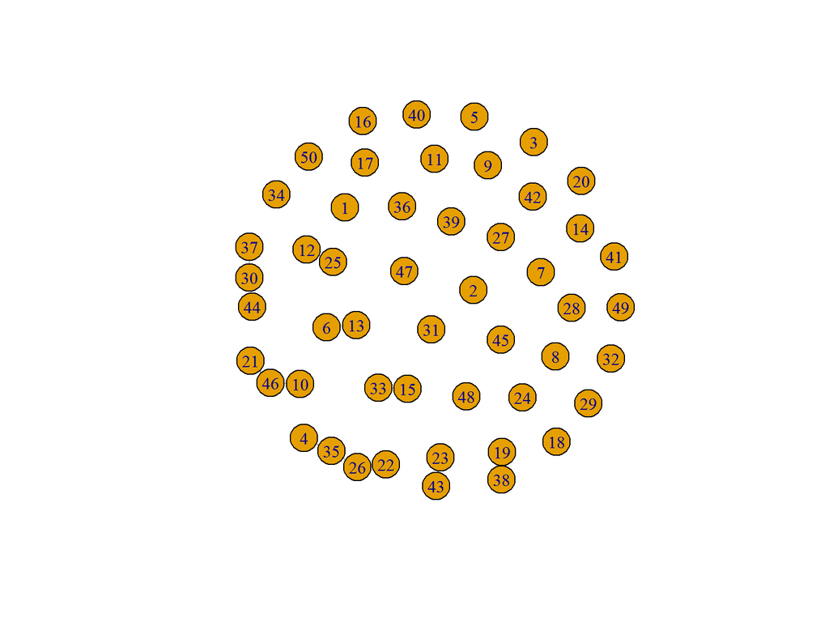

```r
set.seed(1)
plot(random.graph.game(50, p = 0.01))
```

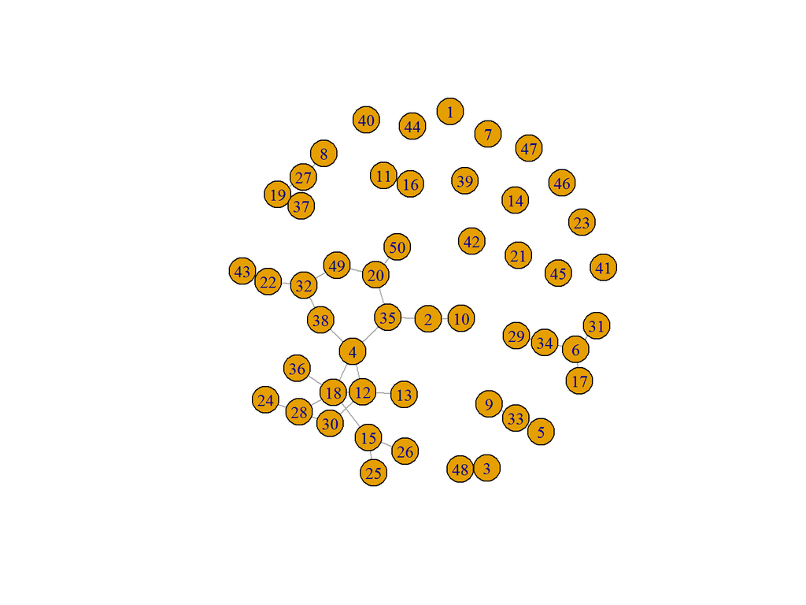

```r
plot(random.graph.game(50, p = 0.03))
```

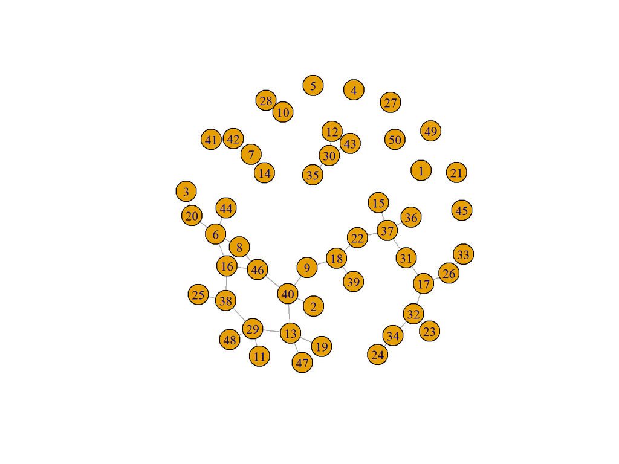

```r
plot(random.graph.game(50, p = 0.05))
```

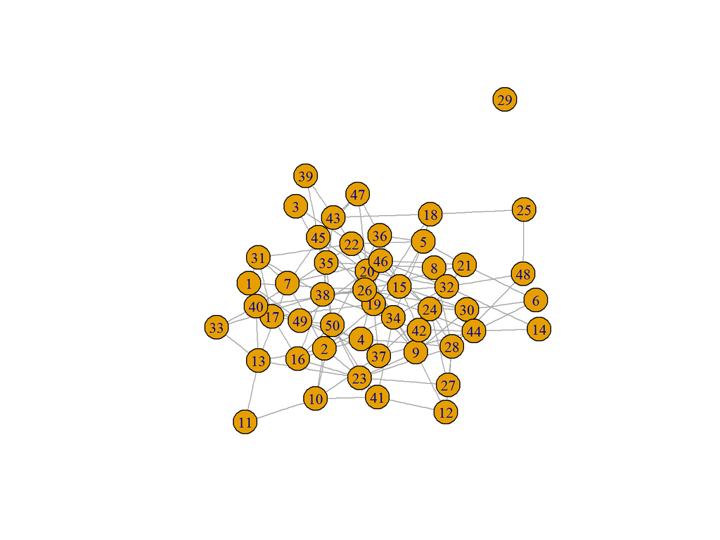

```r
plot(random.graph.game(50, p = 0.1))
```

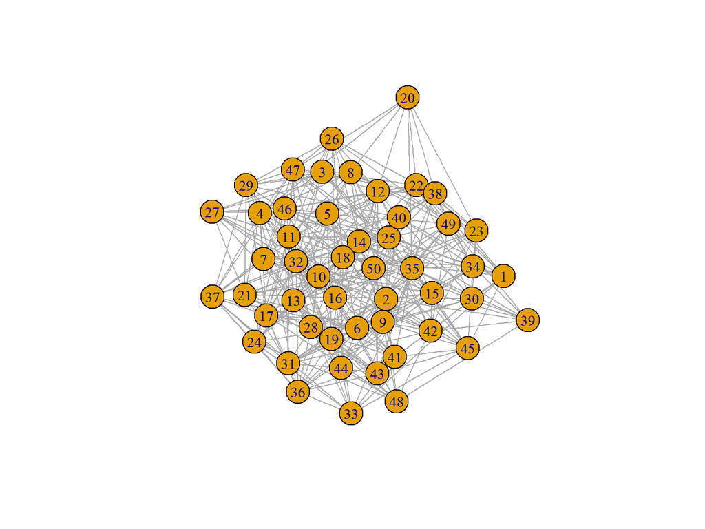

```r
plot(random.graph.game(50, p = 0.3))
```

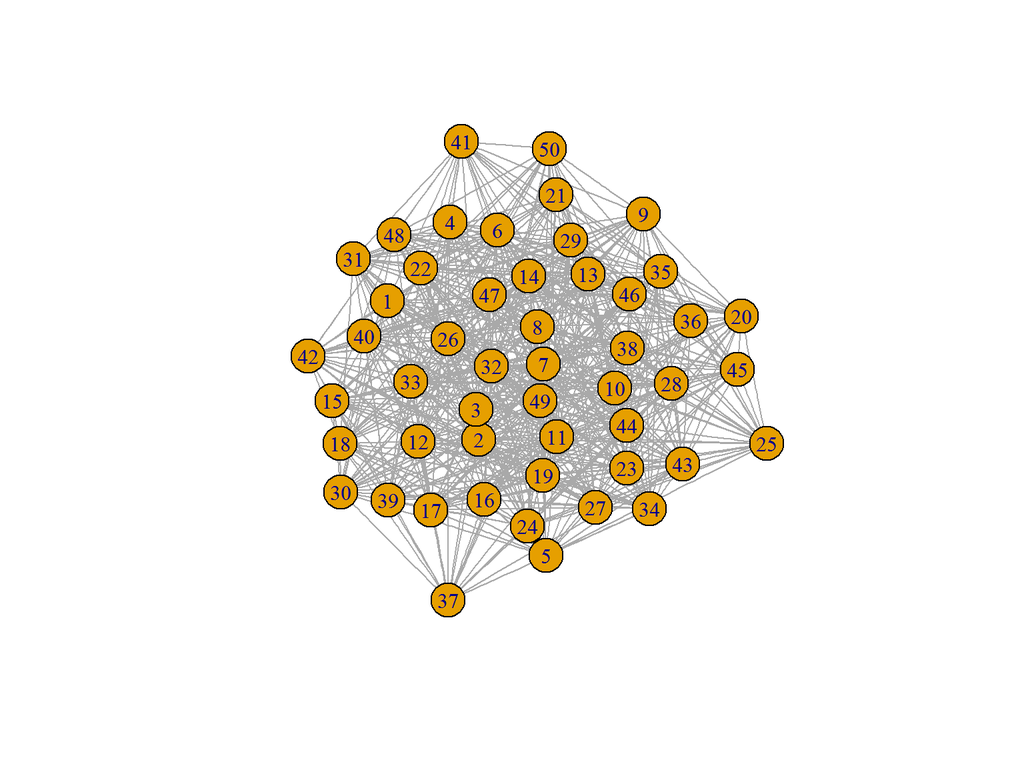

```r
plot(random.graph.game(50, p = 0.5))
```

# Exponential Random Graph Model (ERGM)

- Generate a new random graph based on shapes of network
- Assumption: the structure of a network $y$ can be represent as a exponential random graph with the number of shapes $s(y) = (s_1(y),...,s_k(y))$ as statistics and $\beta = (\beta_1, ..., \beta_k)$ as coefficient
- Let $\beta = \hat{\beta}$ maximize $P(Y = y|\beta) = \exp\left\{\frac{1}{c}\sum_{j=1}^k \beta_j s_j(y) - c_1(\beta) - c_2(y) \right\}$
- Linear regression: Let $\beta = \hat{\beta}$ maximize $f(Y = y|\beta, X) = \exp\left\{\frac{1}{\sigma^2}\sum_{j=1}^p \beta_j (x_j^T y) - c_1(\beta, X) - c_2(y)\right\}$

# ERGM and Network Package

- Install by install.packages(“ergm”)

```r
library(ergm)
data_edgelist = get.edgelist(datag)
datan = network(data_edgelist, directed = FALSE)
class(datag)
```

```
## [1] "igraph"
```

```r
class(datan)
```

```
## [1] "network"
```

- We calculate the probability coefficient of edges for network

```r
model_ergm1 = ergm(datan ~ edges, estimate = "MPLE")
```

```
## Evaluating log-likelihood at the estimate.
```

```r
model_ergm1
```

```
##
## MPLE Coefficients:
##  edges
## -4.562
```

# Summary of ERGM

- All coefficients in ERGM represents an exponential magnitude in probability

```r
summary(model_ergm1)
```

```
##
## ==========================
## Summary of model fit
## ==========================
##
## Formula:   datan ~ edges
##
## Iterations:  NA
##
## Maximum Likelihood Results:
##        Estimate Std. Error MCMC % p-value
## edges -4.562265   0.003463      0  <1e-04 ***
## ---
## Signif. codes:  0 '***' 0.001 '**' 0.01 '*' 0.05 '.' 0.1 ' ' 1
##
## For this model, the pseudolikelihood is the same as the likelihood.
##
##      Null Deviance: 11304871  on 8154741  degrees of freedom
##  Residual Deviance:   938040  on 8154740  degrees of freedom
##
## AIC: 938042    BIC: 938056    (Smaller is better.)
```

# Terms of ERGM (1)

To test the effect of a complex term, we must add all simpler terms to the model

- k-stars represent the concentration of relationships

```r
model_ergm2 = ergm(datan ~ edges + kstar(2:3), estimate = "MPLE")
```

```
## Evaluating log-likelihood at the estimate.
```

```r
summary(model_ergm2)
```

```
##
## ==========================
## Summary of model fit
## ==========================
##
## Formula:   datan ~ edges + kstar(2:3)
##
## Iterations:  NA
##
## Maximum Pseudolikelihood Results:
##          Estimate Std. Error MCMC % p-value
## edges  -7.534e+00  1.223e-02      0  <1e-04 ***
## kstar2  3.334e-02  1.467e-04      0  <1e-04 ***
## kstar3 -1.822e-04  1.402e-06      0  <1e-04 ***
## ---
## Signif. codes:  0 '***' 0.001 '**' 0.01 '*' 0.05 '.' 0.1 ' ' 1
##
## Warning:  The standard errors are based on naive pseudolikelihood and are suspect.
##
##      Null Pseudo-deviance: 11304871  on 8154741  degrees of freedom
##  Residual Pseudo-deviance:   779779  on 8154738  degrees of freedom
##
## AIC: 779785    BIC: 779827    (Smaller is better.)
```

# Terms of ERGM (2)

- Triangles represent a smallest clique in the network

```r
model_ergm3 = ergm(datan ~ edges + kstar(2:3) + triangle, estimate = "MPLE")
```

```
## Evaluating log-likelihood at the estimate.
```

```r
summary(model_ergm3)
```

```
##
## ==========================
## Summary of model fit
## ==========================
##
## Formula:   datan ~ edges + kstar(2:3) + triangle
##
## Iterations:  NA
##
## Maximum Pseudolikelihood Results:
##            Estimate Std. Error MCMC % p-value
## edges    -5.790e+00  1.199e-02      0  <1e-04 ***
## kstar2    1.537e-02  2.192e-04      0  <1e-04 ***
## kstar3   -4.302e-04  2.712e-06      0  <1e-04 ***
## triangle  1.624e-01  5.043e-04      0  <1e-04 ***
## ---
## Signif. codes:  0 '***' 0.001 '**' 0.01 '*' 0.05 '.' 0.1 ' ' 1
##
## Warning:  The standard errors are based on naive pseudolikelihood and are suspect.
##
##      Null Pseudo-deviance: 11304871  on 8154741  degrees of freedom
##  Residual Pseudo-deviance:   437289  on 8154737  degrees of freedom
##
## AIC: 437297    BIC: 437353    (Smaller is better.)
```

# Terms of ERGM (3): More Terms

We can also add [more terms](http://www.inside-r.org/packages/cran/ergm/docs/absdiff) to ERGM

- concurrent: vertices with degree 2 or more

```r
model_ergm4 = ergm(datan ~ edges + concurrent, estimate = "MPLE")
summary(model_ergm4)
```

- threetrail: a path of 3 connected edges

```r
model_ergm5 = ergm(datan ~ edges + kstar(2) + threetrail, estimate = "MPLE")
summary(model_ergm5)
```

- cycle(k): a ring of k edges. In an undirected graph, cycle(3) are triangles, and cycle(4) are squares

```r
model_ergm6 = ergm(datan ~ edges + kstar(2:3) + threetrail + cycle(3:4), estimate = "MPLE")
summary(model_ergm5)
```

# Lecture 6. R Introduction Review

# Preparation

- Download the dataset “[Diamonds.csv](https://github.com/founderfan/Data-Open-Lecture)”

# Our Goals

- Review the contents of first 4 lecture that we learned
- Be familiar with package “data.table” and “ggplot2” in R data analysis